# Lagrange test

Rob Payn

3/18/2022

## Load test data

Load some realistic data for a river. This will load two R6 signal objects representing the upstream conditions (signalIn) and downstream conditions (signalOut) for parcels of water traveling a reach (Lagrangian reference frame). These signals have already been interpoloated such that the time context represents the travel time of the reach.

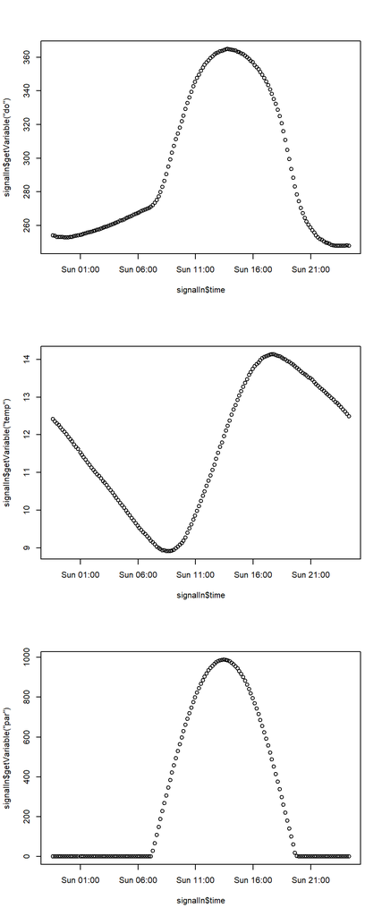

```r
library(metab);

load(file = "../test/lagrange/01_input/2014-09-13/signal.RData");

par(mfrow = c(3, 1));

plot(
   x = signalIn$time,
   y = signalIn$getVariable("do")
);
plot(
   x = signalIn$time,
   y = signalIn$getVariable("temp")
);
plot(
   x = signalIn$time,
   y = signalIn$getVariable("par")
);
```

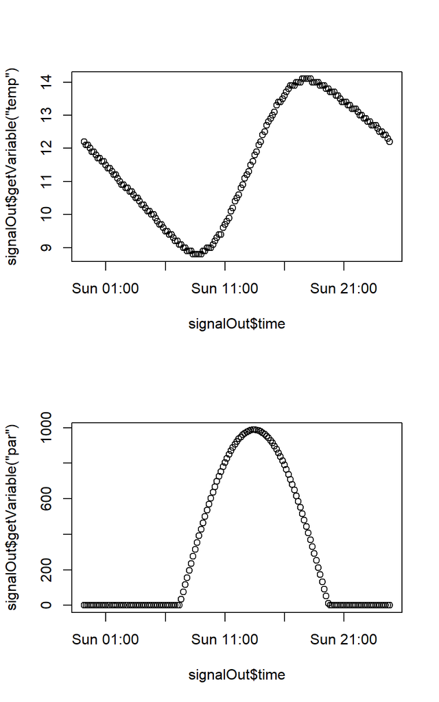

```r
par(mfrow = c(2, 1));

plot(
   x = signalOut$time,
   y = signalOut$getVariable("temp")
);
plot(
   x = signalOut$time,
   y = signalOut$getVariable("par")
);
```

## Model Lagranian DO transformation over the reach

Build the model R6 object with bare minimum arguments.

The k600 is the gas exchange rate (not the velocity) in units of per day. The air pressure is by default in mm Hg, but that can be adjusted by giving the standard air pressure at sea level in any units desired.

```r
rModel <- TwoStationMetabDo$new(
   dailyGPP = 610,
   dailyER = 275,
   k600 = 19.5,
   airPressure = 638,
   upstreamTime = signalIn$time,
   upstreamTemp = signalIn$getVariable("temp"),
   upstreamPAR = signalIn$getVariable("par"),
   upstreamDO = signalIn$getVariable("do"),
   downstreamTime = signalOut$time,
   downstreamTemp = signalOut$getVariable("temp"),
   downstreamPAR = signalOut$getVariable("par")
);
```

Run the model to populate the output attribute. The output attribute is a dataframe with the incremental calculations from the model along with the downstream DO simulation.

This model uses a Crank-Nicolson time finite approximation applied over a single time step representing the transport time for each parcel.

```r
rModel$run();
```

```
##                    time residenceTime       do    cFixation cRespiration doProduction doConsumption doEquilibration
## 1   2014-09-13 23:10:00    0.02222222 257.3704 3.422507e-15     6.111111 3.422507e-15     -6.111111        57.44664
## 2   2014-09-13 23:20:00    0.02222222 257.2130 3.422507e-15     6.111111 3.422507e-15     -6.111111        57.58105
## 3   2014-09-13 23:30:00    0.02222222 256.9215 3.422507e-15     6.111111 3.422507e-15     -6.111111        57.68751
## 4   2014-09-13 23:40:00    0.02222222 256.9147 3.422507e-15     6.111111 3.422507e-15     -6.111111        57.76997
## 5   2014-09-13 23:50:00    0.02222222 257.0409 3.422507e-15     6.111111 3.422507e-15     -6.111111        57.82599
## 6   2014-09-14 00:00:00    0.02222222 257.0917 3.423437e-15     6.111111 3.423437e-15     -6.111111        57.84390
## 7   2014-09-14 00:10:00    0.02222222 257.1655 3.423437e-15     6.111111 3.423437e-15     -6.111111        57.90989
## 8   2014-09-14 00:20:00    0.02222222 257.2890 3.423437e-15     6.111111 3.423437e-15     -6.111111        57.96713
## 9   2014-09-14 00:30:00    0.02222222 257.4147 3.424181e-15     6.111111 3.424181e-15     -6.111111        57.96952
## 10  2014-09-14 00:40:00    0.02222222 257.5776 3.424367e-15     6.111111 3.424367e-15     -6.111111        58.01698
## 11  2014-09-14 00:50:00    0.02222222 257.7552 3.424367e-15     6.111111 3.424367e-15     -6.111111        57.99602
## 12  2014-09-14 01:00:00    0.02222222 258.1489 3.424367e-15     6.111111 3.424367e-15     -6.111111        57.98921
## 13  2014-09-14 01:10:00    0.02222222 258.4844 3.424367e-15     6.111111 3.424367e-15     -6.111111        57.99318
## 14  2014-09-14 01:20:00    0.02222222 258.6286 3.424367e-15     6.111111 3.424367e-15     -6.111111        57.98129
```

[output cut: 210 more lines]

Plot the modeled downstream oxygen concentration and the change in oxygen concentration over the reach for each parcel.

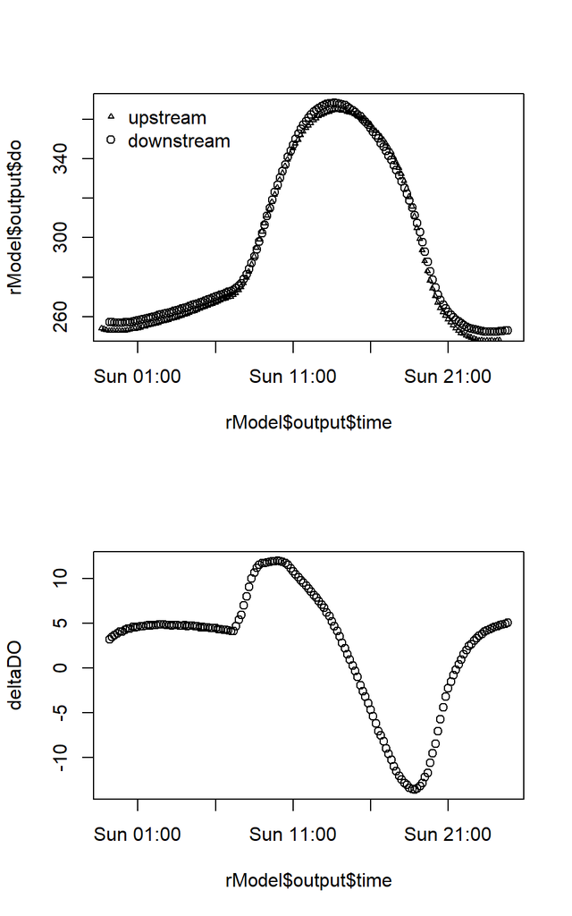

```r
par(mfrow = c(2, 1));

plot(
   x = rModel$output$time,
   y = rModel$output$do
);
points(
   x = signalIn$time,
   y = signalIn$getVariable("do"),
   pch = 2,
   cex = 0.5
)

legend(
   x = "topleft",
   bty = "n",
   legend = c(
      "upstream",
      "downstream"
   ),
   pch = c(
      2,
      1
   ),
   pt.cex = c(
      0.5,
      1
   )
)

deltaDO <- rModel$output$do - signalIn$getVariable("do");

plot(
   x = rModel$output$time,
   y = deltaDO
);
```